# Assignment 2, question 1

This appendix stores all the code for implemented Support Vector Machine (SVMs) in R. Each section corresponds to a part of the discussion both directly and indirectly of that done in the main body of the report.

First all the required libraries are installed and data is imported.

```r
#setup work space, install packages and import libs
suppressMessages(library(e1071))
suppressMessages(library(kernlab))
suppressMessages(library(caret))
suppressMessages(library(ggplot2))
suppressMessages(library(reshape2))
rm(list=ls())
fulldata <- read.csv("blocksTrain.csv")
fulldata <- fulldata[, -1]
```

Next, data processing to define the training and validation sets.

```r
#convert class to a factor
fulldata$class <- as.factor(fulldata$class)
#normalize variables
fulldata[,1:10] <- scale(fulldata[,1:10])
#extract traning and validation stes
set.seed(42)
train <- sample(seq_len(nrow(fulldata)),
                size = ceiling(dim(fulldata)[1]*0.8)) #~80% of the set
Blocks.train <- fulldata[train, ]
Blocks.validation <- fulldata[-train, ]
```

Next generic functions are defined to store model building accuracy.

```r
modelPreformance <- data.frame()
storeModelPreformance <- function(modelName, performance){
  modelPreformance <<- rbind(
    modelPreformance,
    data.frame(
      modelName,
      performance
    )
  )
}
```

The use of the confusionMatrix function from caret is the same as generating a table type confusion matrix. Syntactically this would look like this: `tab <- table(pred = svm.pred, true = Blocks.train$class)` to get the accuracy one would use this: `sum(diag(tab))/sum(tab)`. Miss classification rate would be 1-this number

```r
simple.svm <- svm(class~.,
                  data = Blocks.train,
                  kernel = "radial",
                  gamma = 1,
                  cost = 1)
svm.pred <- predict(simple.svm, Blocks.validation)
confusionMatrix(svm.pred, Blocks.validation$class)
```

```
Confusion Matrix and Statistics

          Reference
Prediction   1   2   3   4   5
         1 886   7   3   5   7
         2   7  51   0   0   0
         3   0   0   0   0   0
         4   1   0   0  12   0
         5   2   0   0   0   4

Overall Statistics

               Accuracy : 0.9675
                 95% CI : (0.9544, 0.9777)
    No Information Rate : 0.9096
    P-Value [Acc > NIR] : 5.242e-13

                  Kappa : 0.794
 Mcnemar's Test P-Value : NA

Statistics by Class:

                     Class: 1 Class: 2 Class: 3 Class: 4 Class: 5
Sensitivity            0.9888  0.87931 0.000000  0.70588 0.363636
Specificity            0.7528  0.99245 1.000000  0.99897 0.997947
Pos Pred Value         0.9758  0.87931      NaN  0.92308 0.666667
Neg Pred Value         0.8701  0.99245 0.996954  0.99486 0.992850
Prevalence             0.9096  0.05888 0.003046  0.01726 0.011168
Detection Rate         0.8995  0.05178 0.000000  0.01218 0.004061
Detection Prevalence   0.9218  0.05888 0.000000  0.01320 0.006091
Balanced Accuracy      0.8708  0.93588 0.500000  0.85242 0.680791
```

Define a generic timer function to calculate how long training takes

```r
start_timer <- function() return(proc.time())
stop_timer <- function(time_start) {
  time_diff <- proc.time() - time_start
  time_diff <- time_diff[1] + time_diff[2] + time_diff[3]
  return(round(as.numeric(time_diff), digits = 2))
}
```

Next, a number of diffrent kernals are experimented with and stored in a data structure plot later.

```r
tt <- start_timer()
## Train the model
model <- svm(class~.,
                data = Blocks.train,
                kernel = "radial",
                gamma = 1,
                cost = 1)
## Evaluate performance
yhat_train <- predict(model, Blocks.train)
yhat_validation <- predict(model, Blocks.validation)
results <- data.frame(Training = round(confusionMatrix(yhat_train, Blocks.train$class)$overall[1], 4),
                      Validation = round(confusionMatrix(yhat_validation, Blocks.validation$class)$overall[1], 4),
                      Duration = round(stop_timer(tt), 2))
storeModelPreformance("SVM Radial", results)
```

```r
tt <- start_timer()
## Train the model
model <- svm(class~.,
                  data = Blocks.train,
                  kernel = "polynomial",
                  gamma = 1,
                  cost = 1)
## Evaluate performance
yhat_train <- predict(model, Blocks.train)
yhat_validation <- predict(model, Blocks.validation)
results <- data.frame(Training = round(confusionMatrix(yhat_train, Blocks.train$class)$overall[1], 4),
                      Validation = round(confusionMatrix(yhat_validation, Blocks.validation$class)$overall[1], 4),
                      Duration = round(stop_timer(tt), 2))
storeModelPreformance("SVM polynomial", results)
```

```r
tt <- start_timer()
## Train the model
model <- svm(class~.,
                  data = Blocks.train,
                  kernel = "sigmoid",
                  gamma = 1,
                  cost = 1)
## Evaluate performance
yhat_train <- predict(model, Blocks.train)
yhat_validation <- predict(model, Blocks.validation)
results <- data.frame(Training = round(confusionMatrix(yhat_train, Blocks.train$class)$overall[1], 4),
                      Validation = round(confusionMatrix(yhat_validation, Blocks.validation$class)$overall[1], 4),
                      Duration = round(stop_timer(tt), 2))
storeModelPreformance("SVM sigmoid", results)
```

```r
tt <- start_timer()
## Train the model
model <- ksvm(class~.,
                  data = Blocks.train,
                  type = "C-svc",
                  kernel = 'anovadot',
                  C = 1, scaled = c())
## Evaluate performance
yhat_train <- predict(model, Blocks.train)
yhat_validation <- predict(model, Blocks.validation)
results <- data.frame(Training = round(confusionMatrix(yhat_train, Blocks.train$class)$overall[1], 4),
                      Validation = round(confusionMatrix(yhat_validation, Blocks.validation$class)$overall[1], 4),
                      Duration = round(stop_timer(tt), 2))
storeModelPreformance("KSVM anovadot", results)
```

```r
tt <- start_timer()
## Train the model
model <- ksvm(class~.,
                  data = Blocks.train,
                  type = "C-svc",
                  kernel = 'splinedot',
                  C = 1, scaled = c())
## Evaluate performance
yhat_train <- predict(model, Blocks.train)
yhat_validation <- predict(model, Blocks.validation)
results <- data.frame(Training = round(confusionMatrix(yhat_train, Blocks.train$class)$overall[1], 4),
                      Validation = round(confusionMatrix(yhat_validation, Blocks.validation$class)$overall[1], 4),
                      Duration = round(stop_timer(tt), 2))
storeModelPreformance("KSVM splinedot", results)
```

```r
tt <- start_timer()
## Train the model
model <- ksvm(class~.,
                 data = Blocks.train,
                 type = "C-svc",
                 kernel = 'tanhdot',
                 C = 1,
                 scaled = c())
## Evaluate performance
yhat_train <- predict(model, Blocks.train)
yhat_validation <- predict(model, Blocks.validation)
results <- data.frame(Training = round(confusionMatrix(yhat_train, Blocks.train$class)$overall[1], 4),
                      Validation = round(confusionMatrix(yhat_validation, Blocks.validation$class)$overall[1], 4),
                      Duration = round(stop_timer(tt), 2))
storeModelPreformance("KSVM tanhdot", results)
```

Print average results in a table. Order by training

```r
modelPreformance[order(modelPreformance$Training),]
```

[output not shown]

Lastly create some graphs for our results!

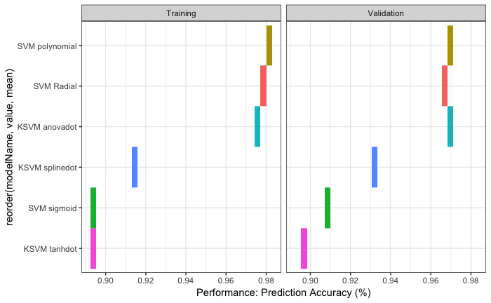

```r
res_acc <- melt(modelPreformance,
                id.vars = c('modelName'),
                measure.vars = c('Training', 'Validation'))
res_time <- melt(modelPreformance,
                 id.vars = c('modelName'),
                 measure.vars = c('Duration'))
## Prediction Accuracy
ggplot(data = res_acc, aes(x = reorder(modelName, value, mean), y = value, fill = modelName)) +
  geom_bin2d() +
  facet_grid(~ variable) +
  ylab("Performance: Prediction Accuracy (%)")+
  coord_flip() +
  guides(fill = FALSE, color = FALSE, linetype = FALSE, shape = FALSE)+
  theme_bw()
```

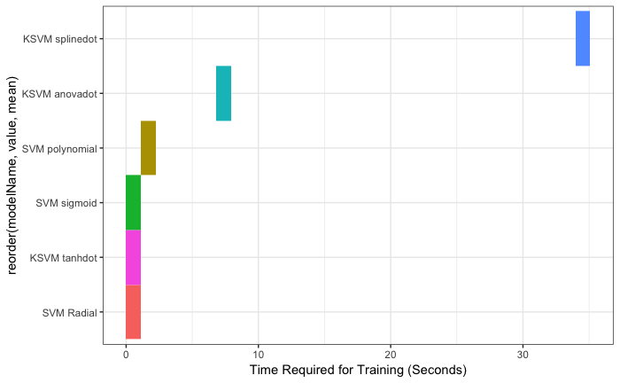

```r
## Time Required for Training
ggplot(data = res_time, aes(x = reorder(modelName,value, mean), y = value, fill = modelName)) +
  geom_bin2d() +
  ylab("Time Required for Training (Seconds)")+
    coord_flip() +
  guides(fill = FALSE, color = FALSE, linetype = FALSE, shape = FALSE)+
  theme_bw()
```

Tuning or Hyper parameter optomization.

If the cost is too high then it will mean a high penalty for non-seperable points and as a result the model may store too many support vectors which will lead to over fitting. however, if the cost value is too small then the model may end up with too few support vectors and the model then will not be accurate.

The $\gamma$ (gamma) has to be tuned to better fit the hyperplane to the data. It is responsible for the linearity degree of the hyperplane, and for that, it is not present when using linear kernels. The smaller $\gamma$ is, the more the hyperplane is going to look like a straight line. If $\gamma$ is too great, the hyperplane will be more curvy and might delineate the data too well and lead to overfitting.

```r
tt <- start_timer()
tune.out <- tune(svm, class~.,
                 data = Blocks.train,
                 kernel = "polynomial",
                 ranges = list(gamma = c(2^-13,2^-2), cost = c(2^-0,2^13)))

plot(tune.out)

# show best model
best.model <- tune.out$best.model
yhat_train <- predict(best.model, Blocks.train)
yhat_validation <- predict(best.model, Blocks.validation)
storeEnsembleValue(yhat_validation) # store the votes from this model to form part of the ensamble selection

results <- data.frame(Training = round(confusionMatrix(yhat_train,
                                                       Blocks.train$class)$overall[1], 4),
                      Validation = round(confusionMatrix(yhat_validation,
                                                         Blocks.validation$class)$overall[1], 4),
                      Duration = round(stop_timer(tt), 2))
storeModelPreformance("Tuned SVM polynomial", results)
```

[output not shown]

We can also try using the caret train function to expand over a grid of posible values.

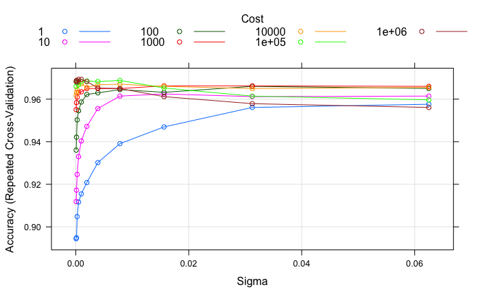

```r
library(caret)
library(caretEnsemble)
tt <- start_timer()
TrainCtrl1 <- trainControl(method = "repeatedcv",
                           number = 5,
                           repeats = 1,
                           verbose = FALSE)
SVMgrid <- expand.grid(sigma = 2^(-14:-4),
                       C = 10^(0:6))
modelSvmRRB <- train(class~.,
                     data = Blocks.train,
                     method="svmRadial",
                     trControl=TrainCtrl1,
                     tuneGrid = SVMgrid,
                     verbose=FALSE)
plot(modelSvmRRB)
```

```r
best.model <- modelSvmRRB$finalModel
yhat_train <- predict(modelSvmRRB, Blocks.train)
yhat_validation <- predict(modelSvmRRB, Blocks.validation)
results <- data.frame(Training = round(confusionMatrix(yhat_train, Blocks.train$class)$overall[1], 4),
                      Validation = round(confusionMatrix(yhat_validation, Blocks.validation$class)$overall[1], 4),
                      Duration = round(stop_timer(tt), 2))
storeModelPreformance("Caret SVM, tuned radial", results)
```

Print average results in a table. Order by training

```r
modelPreformance[order(modelPreformance$Training, decreasing = TRUE),]
```

[output not shown]

Lastly create some graphs for our results!

```r
res_acc <- melt(modelPreformance,
                id.vars = c('modelName'),
                measure.vars = c('Training', 'Validation'))

res_time <- melt(modelPreformance,
                 id.vars = c('modelName'),
                 measure.vars = c('Duration'))

## Prediction Accuracy
ggplot(data = res_acc,
       aes(x = reorder(modelName, value, mean), y = value, fill = modelName)) +
  geom_bin2d() +
  facet_grid(~ variable) +
  ylab("Performance: Prediction Accuracy (%)")+
  xlab("Model")+
  coord_flip() +
  guides(fill = FALSE, color = FALSE, linetype = FALSE, shape = FALSE)+
  theme_bw()

## Time Required for Training
ggplot(data = res_time,
       aes(x = reorder(modelName,value, mean), y = value, fill = modelName)) +
  geom_bin2d() +
  ylab("Time Required for Training (Seconds)")+
  xlab("Model")+
    coord_flip() +
  guides(fill = FALSE, color = FALSE, linetype = FALSE, shape = FALSE)+
  theme_bw()
```

[output not shown]

```r
write.csv(ensamble, "EnsambleVotesQuestion1.csv")
```